# POLS 1600: Random Variables, Probability Distributions, and Expected Values and Variances

Updated ‘January 27, 2022’

# Oveview

In these notes we’ll introduce the concept of random variables and probability distributions

- Random variables are how we describe events in numeric terms
- Probability distributions are how we summarize the probability of events (described by random variables) in terms of parameters that define the shape of the probability distirbution.

Then, we’ll take a more detailed look at concepts we’ve used in this course:

- Expected Values, which are probability weighted averages describe the “center” or the “balancing point” of a probability distribution
- Variances, which describe the spread of distribution (around it’s expected value)

# Random Variables

- Random variables assign numeric values to each event in an experiment.
  - Mutually exclusive and exhaustive, together cover the entire sample space.
- Discrete random variables take on finite, or [countably infinite](http://mathworld.wolfram.com/CountablyInfinite.html) distinct values.
- Continuous variables can take on an uncountably infinite number of values.

## Example: Toss Two Coins

- $S={TT,TH,HT,HH}$
- Let $X$ be the number of heads
  - $X(TT)=0$
  - $X(TH)=1$
  - $X(HT)=1$
  - $X(HH)=2$

# Probability Distributions

- Broadly probability distributions provide mathematical descriptions of random variables in terms of the probabilities of events. They come in two forms, which as we’ll see really contain the same information
- Probability Mass/Density Functions
  - Discrete variables have probability mass functions (PMF)
  - Continuous variables have probability density functions (PDF)
- Cumulative Density Functions
  - Discrete: Summation of discrete probabilities
  - Continuous: Integration over a range of values

## Discrete distributions

- **Probability Mass Function (pmf):** $f(x)=p(X=x)$
- Assigns probabilities to each unique event such that Kolmogorov Axioms (Positivity, Certainty, and Additivity) still apply
  - **Positivity** For any event A, P(A) ≥ 0. In English, that’s “For any event A, the probability of A is greater or equal to 0”.
  - **Certainty** For S, the sample space, or set of all possible outcomes, the Pr(S)=1. That is, anytime this experiment is performed, something happens.
  - **Additivity** If events A and B are mutually exclusive outcomes (if A happens, B can’t happen, If B happens, A can’t happen), then the probabilty of A or B happening is $Pr(A \cup B) = Pr(A) + Pr(B)$, is the probability of A plus the probability of B
- **Cumulative Distribution Function (cdf)** $F(x_j)=p(X\leq x)=\sum_{i=1}^{j}p(x_i)$
- Sum of the probability mass for events less than or equal to $x_j$

## Example: Toss Two coins

- $S={TT,TH,HT,HH}$
- Let $X$ be the number of heads
  - $X(TT)=0$
  - $X(TH)=1$
  - $X(HT)=1$
  - $X(HH)=2$
- $f(X=0)=p(X=0)=1/4$
- $f(X=1)=p(X=1)=1/2$
- $F(X\leq 1) = p(X \leq 1)= 3/4$

## PMF and CDF of a die

Below I graph the pmf and cdf of a die

```
Warning: Removed 2 rows containing missing values (geom_segment).
```

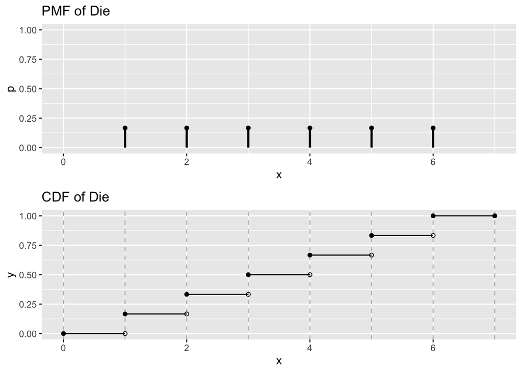

Each side has equal probability of occurring (1/6). The probability that you roll a 2 or less P(X<=2) = 1/6 + 1/6 = 1/3

## Continuous distributions

- **Probability Density Functions (PDF):** $f(x)$
  - Assigns probabilities to events in the sample space such that Kolmogorov Axioms still apply
  - But… since their are an infinite number of values a continuous variable could take, p(X=x)=0, that is, the probability that X takes any one specific value is 0.
- **Cumulative Distribution Function (CDF)** $F(x)=p(X\leq x)=\int_{-\infty}^{x}f(x)dx$
  - Instead of summing up to a specific value (discrete) we integrate over all possible values up to $x$
  - Probability of having a value less than x

First, a brief aside on integral calculus:

What’s the area of the rectangle? $base\times height$

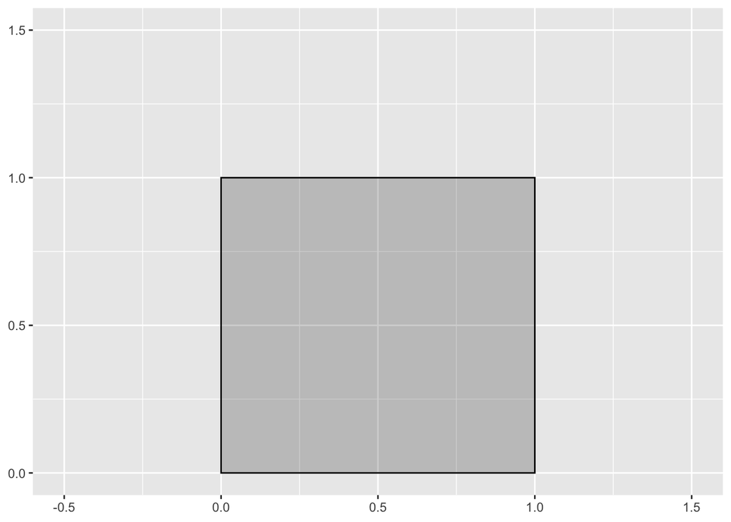

How would we find the area under a curve?

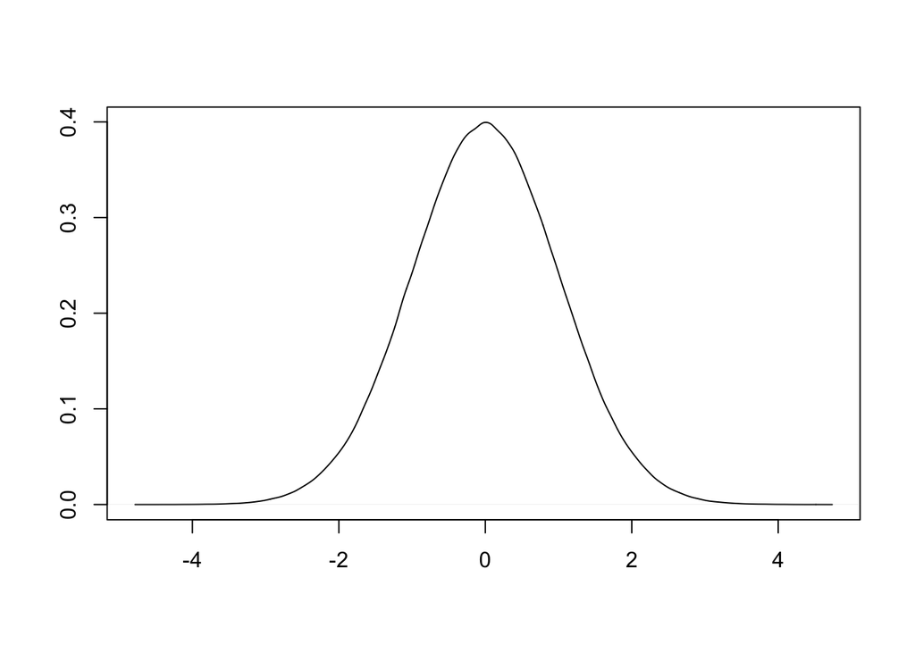

Well suppose we added up the areas of a bunch of rectangles roughly whose height’s approximated the height of the curve?

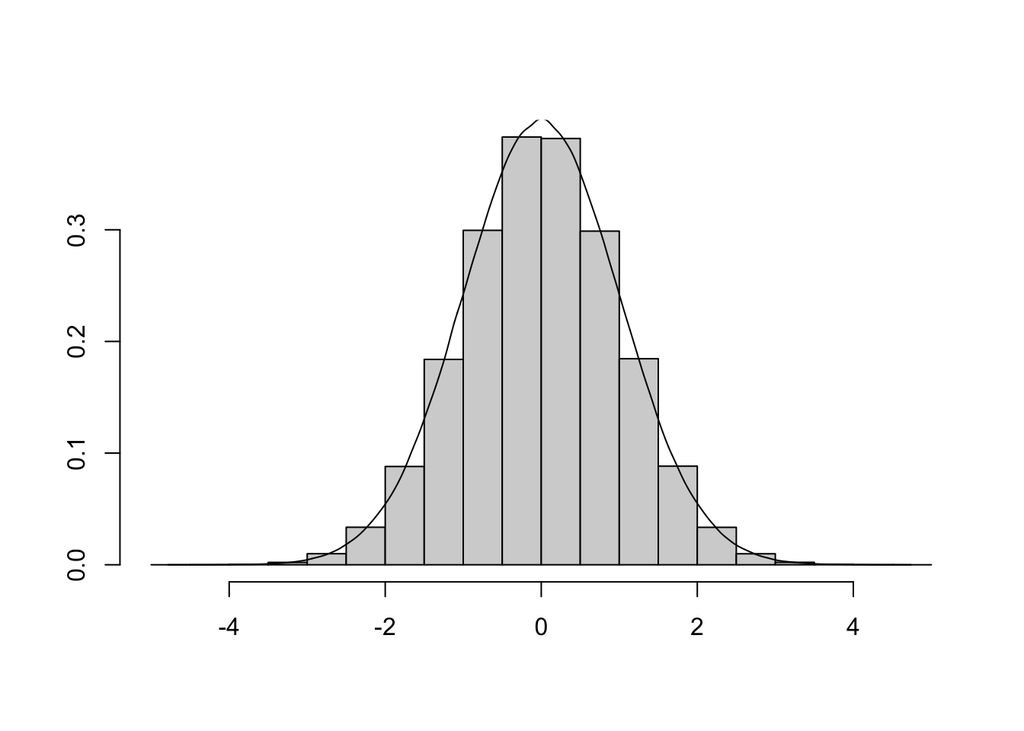

Can we do any better? Let’s make the rectangles smaller

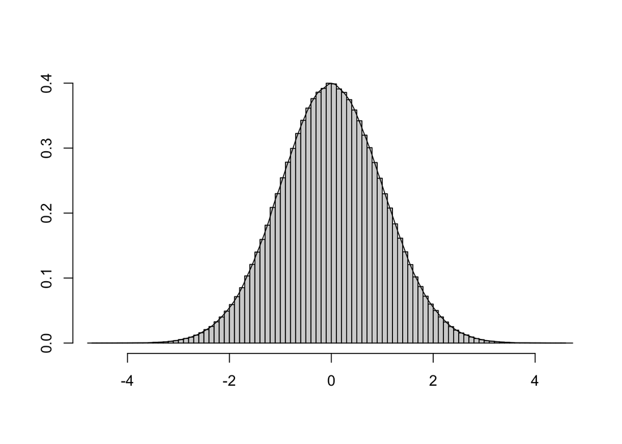

## Link between PDF and CDF

If
$$F(x)=p(X\leq x)=\int_{-\infty}^{x}f(x)dx$$
Then by the fundamental theorem of calculus

$$\frac{d}{dx}F(x)=f(x)$$

In words - the PDF ($f(x)$) is the derivative (rate of change) of the CDF ($F(X)$) - the CDF describes the area under the curve defined by f(x) up to x

## Properties of the CDF

- $0\leq F(x) \leq 1$
- $F$ is non-decreasing and right continuous
- $\lim_{x\to-\infty}F(x)=0$
- $\lim_{x\to\infty}F(x)=1$
- For all $a,b \in \mathbb{R}$ s.t. $a<b$

$$p(a < X \leq b) = F(b)- F(a) = \int_a^b f(x)dx$$

## Recall the PMF and CDF of a die

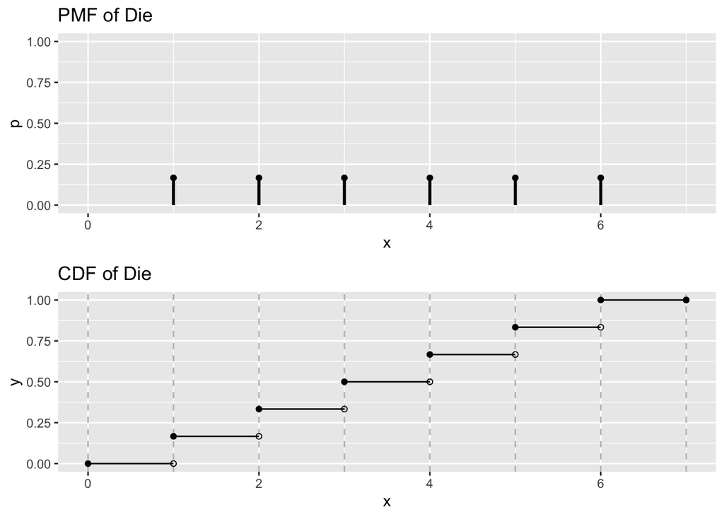

## What’s the probability

- $p(X=1)...p(X=6) =$$1/6$
- $p( 2 < X \leq 5) =$$F(5)-F(2)=5/6-2/6=3/6=1/2$

# Common Probablity Distirbutions

In this course, we’ll use probability distributions to

- Model the data generating process as a function of parameters we can estimate
- To perform inference based on asymptotic theory (statements about how statistics would be have as our sample size approached infinity)

There are a lot of probability distributions:

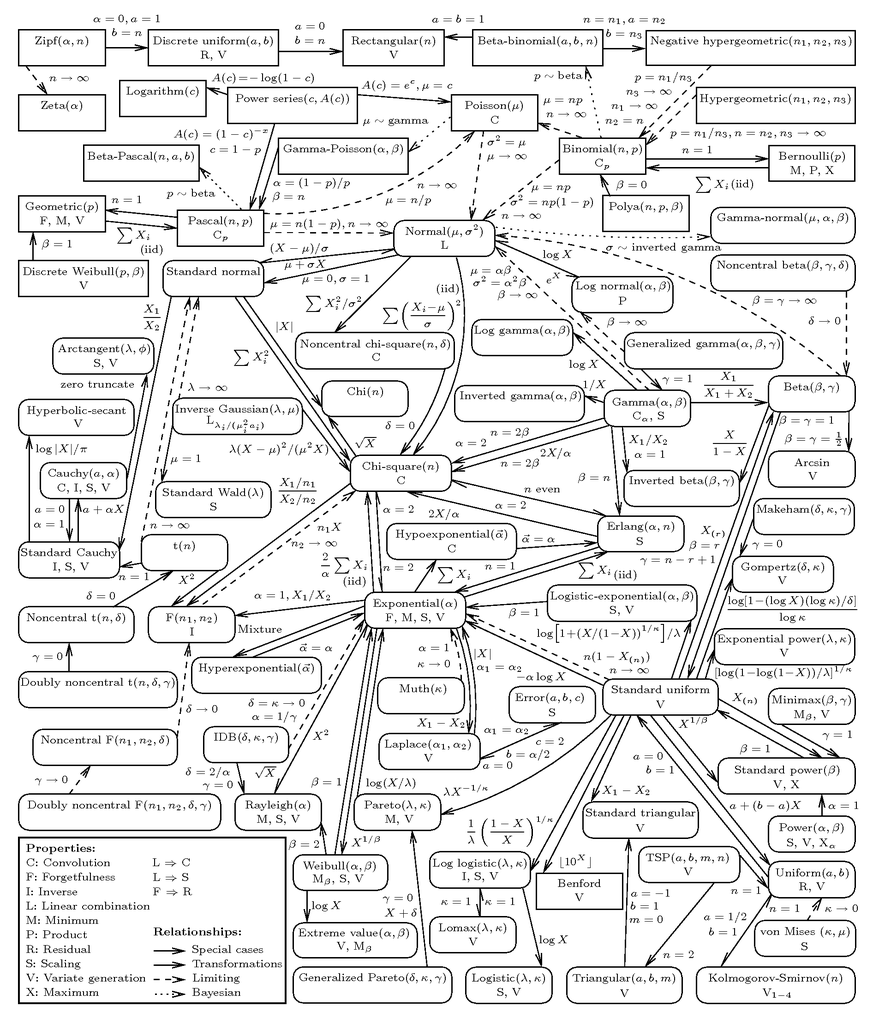

Fortunately, the distributions you need to know to really master data science, is probably more something like

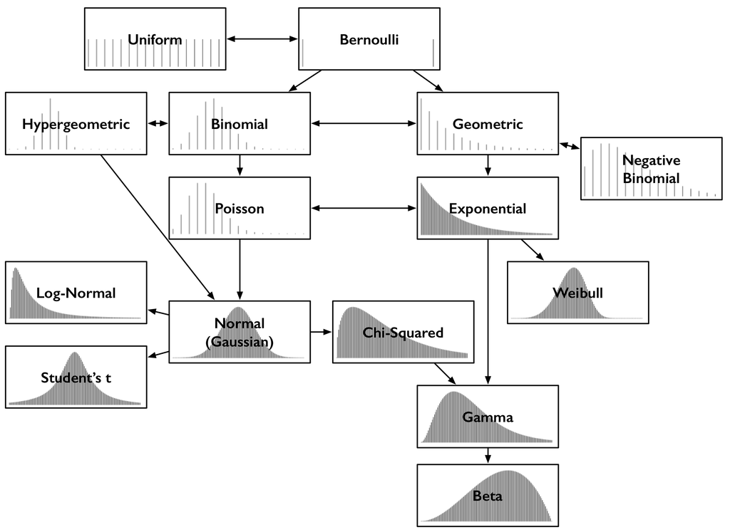

And the distributions we’ll work with the most in this class are an even smaller subset.